# Test of impact package for use in n of 1 experiment with electronic momentary assesment

Jakob A. Kaminski

2 4 2021

## Possible paths on how medication symptoms and side-effects are related

We here show a simplistic path model on how symptoms and side-effects could be related.

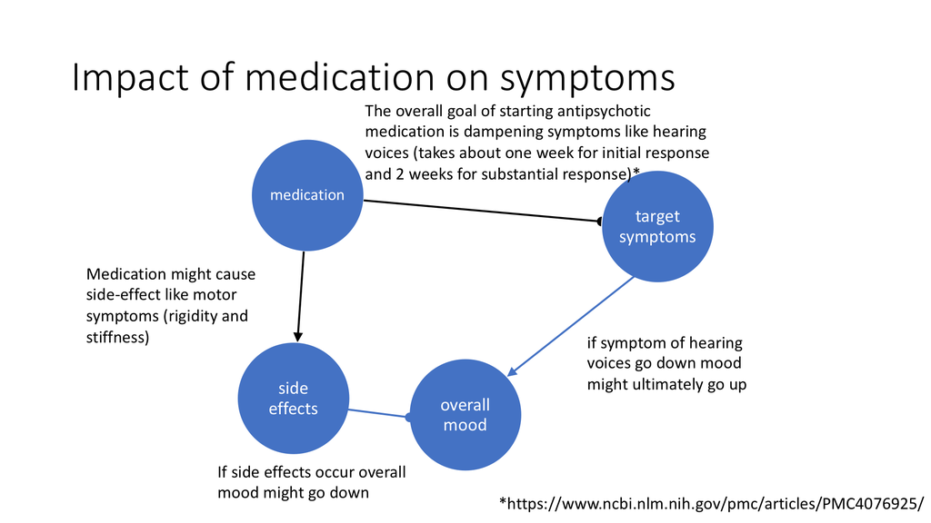

Due to this complex interactions and long intervals (2-6 weeks) between outpatient visits and side-effects that occur at shorter time periods (within hours and after a few days) it is hard to disentanle cause and consequences of symptom and side-effects when starting medication.

## Electronic momentary assesment allows symptom monitoring and evaluation

Day by day smartphone based symptom assesment and a visualisation of the course for the symptomsmight allow a better evaluation of sympotms at a follow-up appointment.

## Impact for EMA data

Test of impact package for use in n of 1 experiment with electronic momentary assesment. We here created a dummy time series data of n of 1 experiment of two symptoms that were tracked every day on a scale from 0 to 3:

```
##            symptom1 symptom2
## 2021-01-01        0        1
## 2021-01-02        0        0
## 2021-01-03        1        0
## 2021-01-04        1        0
## 2021-01-05        1        3
## 2021-01-06        1        1
```

## Plots

Time series plot of dummy data of two electronic momentary assessment scales of hypothetical symptoms with vertical line at date of medication start (time point of impact, 2021-05-02) :

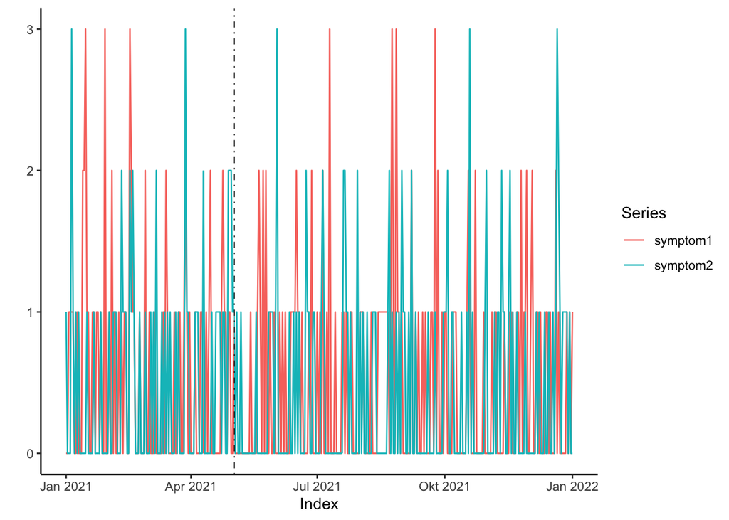

For a statistical evaluation of the medication effect we looked at the period from medication start to two weeks therafter. With the impact package we are able to infer a quantitative estimate of the counterfactual via a synthetic control and thus estimate the causal effect. Impact plot of impact estimate at medication intake according to K. Brodersen Annals of Applied Statistics 2015 https://arxiv.org/abs/1506.00356 for documentation http://google.github.io/CausalImpact/CausalImpact.html:

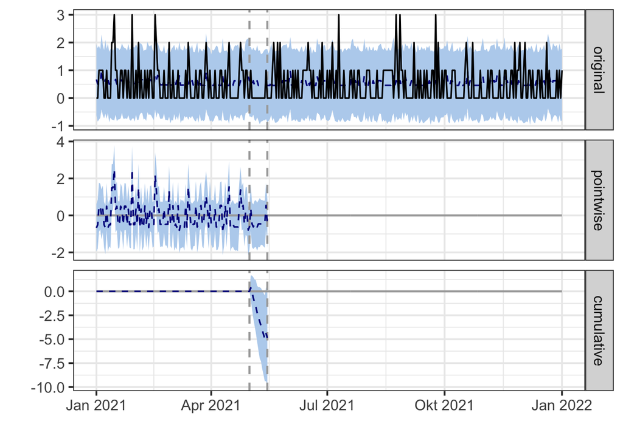

And here the narrative summary of the impact estimation:

```
## Posterior inference {CausalImpact}
##
##                          Average         Cumulative
## Actual                   0.14            2.00
## Prediction (s.d.)        0.49 (0.18)     6.86 (2.54)
## 95% CI                   [0.13, 0.85]    [1.83, 11.84]
##
## Absolute effect (s.d.)   -0.35 (0.18)    -4.86 (2.54)
## 95% CI                   [-0.7, 0.012]   [-9.8, 0.166]
##
## Relative effect (s.d.)   -71% (37%)      -71% (37%)
## 95% CI                   [-143%, 2.4%]   [-143%, 2.4%]
##
## Posterior tail-area probability p:   0.03128
## Posterior prob. of a causal effect:  96.872%
##
## For more details, type: summary(impact, "report")
```

[output not shown]